# TrainingLog20160401

This is a log for the first training session with wild types, no injections, the door can be opened when nosepoked in the time window of 19:00-23:59, but only after a light cue appears between 2-4s after a visit occours.

This R markdown requires ggplot2 package and will install it if it doesn't exist.

It read the “animals.txt”, “visits.txt” and “nosepokes.txt” files, removes all non-first nosepokes

and assigns animal name for each event as a factor(visit and nosepoke).

This is the visit count with the appropriate plot

```
##
## Animal 10  Animal 4
##       217       289
```

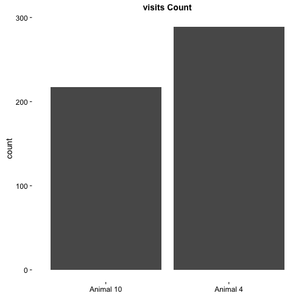

Visits over time for each animal

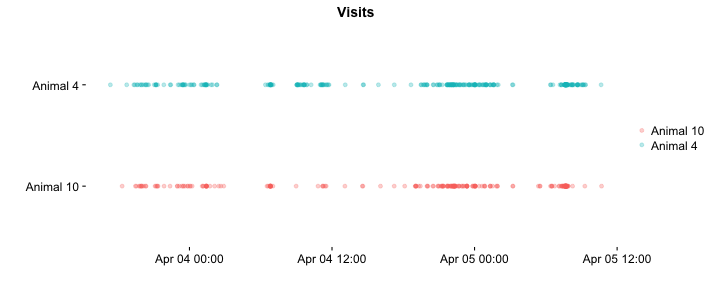

[output not shown]

[output not shown]

[output not shown]

[output not shown]

[output not shown]

[output not shown]

[output not shown]

This is the hour with the maximun number of visits

```
## [1] "2016-04-05 07:00:00 IDT"
```

This is the nosepokes count with the appropriate plot

```
##
## Animal 10  Animal 4
##       174       221
```

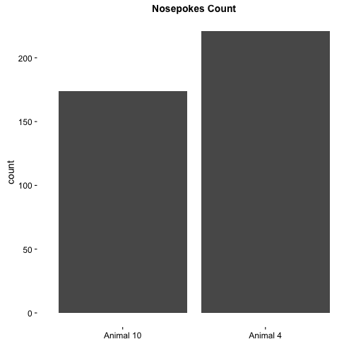

Nosepokes over time for each animal

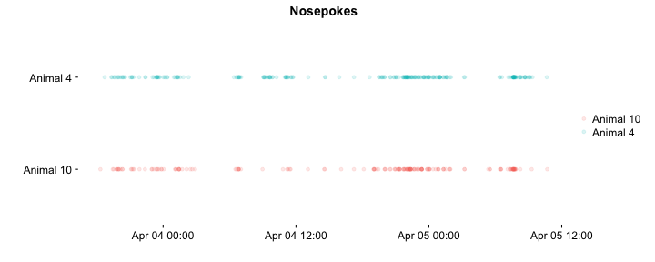

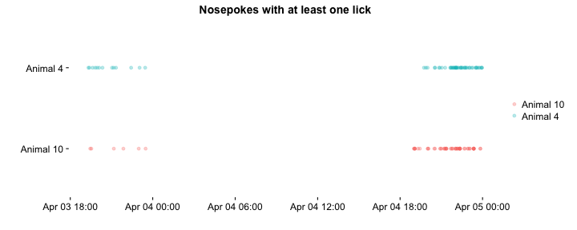

This is a plot showing the fraction of errors per time window.

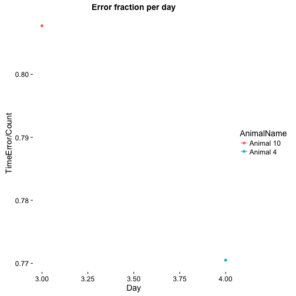

```
##   AnimalName Day Count TimeError
## 1  Animal 10   3    26        21
## 2   Animal 4   4    61        47
## 3  Animal 10   3    26        21
## 4   Animal 4   4    61        47
```